# Bruhn_C11_2

## C11.20 縦補強材（またはウェブスチフナ）の平均応力および最大応力

ダブル縦補強材（ウェブの両側に配置されたスチフナ）について、その長さ方向の平均応力は以下の式によって計算できる：

$$ —(57)

式(57)は、スチフナの両側のパネルにおける $f_s$ 、 $k$ 、 $\alpha$ の値が同一であることを前提としている。これらが異なる場合は、平均値を使用するか、または最大のせん断値を用いて安全側の確認を行う必要がある。

### シングル縦補強材（またはウェブの片側のみのスチフナ）

シングル縦補強材の応力 $f_u$ も同様の方法で得られるが、比率 $A_u / dt$ が $A_{ue} / dt$ に置き換えられる。ここで、

$$

—(58)

シングル縦補強材の場合、 $f_u$ は依然として縦補強材の長さ方向の平均値であるが、それは縦補強材とウェブを結ぶリベット線上におけるウェブの中立面にのみ適用される。任意の断面において、縦補強材がウェブの張力によって偏心荷重を受ける柱として機能するため、圧縮応力はウェブからの距離が長くなるにつれて減少する。したがって、断面全体に均一に応力が分布することを前提とした局所圧壊の公式は適用されない。

### 縦補強材の最大応力

縦補強材内の応力 $f_u$ は、梁の中立軸（またはその付近）での最大値から、縦補強材の端部での最小値（「ガセット効果」）まで変化する。最大値は次の方程式によって与えられる：

$$ —(59)

ここで、 $\left( f_{u\max} / f_u \right)$ は、ウェブが座屈したばかりのときの比率の値であり、Fig. C11.21 がこの比率の値を与える。

## C11.21 斜め引張の角度

$k$ および $f_u / f_s$ を決定した後、斜め引張の方向と梁の軸との間の角度 $\alpha$ は、Fig. C11.22 を用いて決定できる。

## C11.22 縦補強材の許容応力

4つの破損モードが考えられる。

1. 柱としての破損（Column Failure）
2. 強制圧壊破損（Forced Crippling Failure）
3. 自然圧壊破損（Natural Crippling Failure）
4. ウェブおよびスチフナの全体的な弾性不安定破損

### 柱としての破損 (Column Failure)

通常の意味での柱の破損（事前のたわみを伴わない、不安定性による破損）は、ダブル縦補強材においてのみ可能である。柱のたわみが始まると、縦補強材はウェブを元の平面から押し出す。その結果、ウェブの引張力がウェブの平面に対して垂直な成分を発生させ、これが縦補強材を元の位置に押し戻そうとする。この支持作用は、以下の経験式によって与えられる、減少した縦補強材の「有効」柱長さ $L_e$ を使用することによって考慮される：

$$ —(60)

柱破損が発生する応力 $f_u$ は、図に示されるように、細長比 $L_e / \rho$ を持つ標準的な柱曲線を用いて見つけることができる。

シングル縦補強材における「柱」破損の問題は、これまであまり調査されておらず、試験結果は理論結果と大きく異なっている。強度設計のために、以下の2つの基準が提案されている：

1. 応力 $f_u$ は、縦補強材の材料の柱降伏応力より大きくなってはならない。これは、縦補強材が偏心荷重を受ける圧縮部材として機能することを考慮している。
2. 縦補強材の図心における応力（断面全体の平均応力）は、細長比 $h_u / 2\rho$ に対する許容柱応力より大きくなってはならない。これは、非常に細長い縦補強材で観察されている2波形の座屈破損を考慮しようとする試みである。

### 強制圧壊破損 (Forced Crippling Failure)

ウェブのせん断座屈は、ウェブに取り付けられたフランジ内の縦補強材の座屈を強制する。特に縦補強材のフランジがウェブよりも薄い場合に顕著である。これらの座屈は、フランジに作用する圧縮力にモーメントアームを与え、その結果、厳しい応力状態を引き起こす。取り付けられたフランジの座屈は、次に突出したフランジの座屈を誘発する。

シングル縦補強材では、突出したフランジは、圧縮応力がウェブからの距離とともに減少するという事実によって、かなりの程度緩和される。したがって、シングル縦補強材の許容応力は、ダブル縦補強材のそれよりもやや高くなる。強制圧壊は局所的な性質のものであるため、平均値ではなく、縦補強材応力のピーク値 $f_{u\max}$ に依存すると仮定される。

最終的な崩壊が発生する縦補強材応力は、以下の実験的方法によって得られる：

1. 完全に弾性的な縦補強材材料の $F_{u\max}$ の許容値を以下の公式によって計算する：

#### 2024-T3 アルミニウム合金の場合：

$$

F_u = 21000 k^{2/3} (t_u / t)^{1/3}

$$ —(61a)

$$

F_u = 26000 k^{2/3} (t_u / t)^{1/3}

$$ —(61b)

#### 7075-T6 アルミニウム合金の場合：

$$

F_u = 26000 k^{2/3} (t_u / t)^{1/3}

$$ —(61c)

$$

F_u = 32500 k^{2/3} (t_u / t)^{1/3}

$$ —(61d)

2. $F_u$ が縦補強材材料の比例限度を超える場合は、許容値として圧縮歪み $F_u / E$ に対応する応力を使用する。

$F_u$ は、Fig. C11.38 から様々な材料について得ることもできる。

### 自然圧壊破損 (Natural Crippling Failure)

「自然圧壊破損」という用語は、縦補強材の断面全体に均一に分布した圧縮応力に起因する圧壊破損を指すために使用される。この定義により、これはダブル縦補強材においてのみ発生し得る。自然圧壊破損を回避するために、縦補強材内のピーク応力 $F_{u\max}$ は、 $L/\rho \to 0$ に対する断面の圧壊応力未満である必要がある。実際の設計において、圧壊破損が支配的な要因になることはないようである。

### ウェブおよび縦補強材の全体的な弾性不安定性

これまでの試験経験では、設計において全体的な弾性不安定性を考慮する必要はないことが示されている。縦補強材が、柱としての作用、またはウェブのせん断強度と大差ないせん断荷重での強制圧壊によって破損するように設計されていれば、ウェブシステムは全体的な弾性不安定性に対して安全であるようである。

## C11.23 ウェブの設計

設計目的のために、ベイ内の公称ウェブせん断応力のピーク値は以下のように設定される：

$$

f_{s} = f_s (1 + k C_1)(1 + k C_2)

$$ —(62)

係数 $C_1$ および $C_2$ の値を決定するには、Fig. C11.23 および Fig. C11.24 を参照されたい。 $C_1$ 項は、斜め引張場の角度 $\alpha$ が45度から外れることを考慮するための補正係数である。 $C_2$ は、梁フランジの柔軟性に起因する応力集中を考慮する。

### 許容せん断応力 $F_s$

許容せん断応力 $F_s$ は試験によって決定され、斜め引張係数 $k$ の値、およびウェブとフランジ、ウェブと縦補強材の結合の詳細に依存する。Fig. C11.25 は、2つのアルミニウム合金に対する経験的な許容曲線を示している。これらの曲線にはリベット係数に対する許容値が含まれていることに注意されたい。これらの曲線にこの係数を含めることができるのは、総断面（すなわち、リベット穴による減少がない断面）に基づく極限せん断応力が、リベット係数の通常の範囲（ $C_R > 0.6$ ）においてほぼ一定であることが試験によって示されているためである。

他の材料の許容応力については、Fig. C11.42 を参照されたい。

### ウェブの永久座屈

永久せん断座屈の発生に関する確認は、Fig. C11.46 を用いて行うことができる。この図において、 $F_{s_{\text{P.B.}}}$ は、永久座屈が発生しない許容ウェブ総せん断応力である。空軍は通常、制限荷重において永久座屈が発生しないことを規定している。

## C11.24 リベットの設計

### ウェブとフランジを結ぶリベット

ウェブからフランジリベットに作用する1インチあたりの荷重は、以下のように算出される：

$$

R’’ = (1 + 0.414 k)

$$ —(63)

ダブル縦補強材の場合、ウェブと縦補強材を結ぶリベットは、柱としての破損が発生するまで2つの縦補強材が一体となって機能するのに十分な縦方向せん断強度を提供しなければならない。縦補強材において必要とされる全せん断強度（すべてのリベットの一面せん断強度の合計）は、以下のように与えられる：

$$ —(64)

ここで、

$F_{co}$ = 縦補強材材料の柱降伏強度。（ $F_{co}$ が ksi で表される場合、 $R_{\text{total}}$ は kips になる。）

$Q$ = ウェブの中立面における軸まわりの、一方の縦補強材の断面の静的モーメント（ $\text{in}^3$ ）。

$b$ = 縦補強材の突出脚の幅。

$h_u / L_e$ = 公式(60)から得られる比率。

リベットはまた、座屈した板がスチフナから剥がれるのを防ぐのに十分な引張強度を持たなければならない。必要な強度は以下の基準によって与えられる：

リベット1インチあたりの引張強度 $\ge 0.15 \times t \times F_{tu}$ —(65)

ここで、 $F_{tu}$ はウェブの引張強度である。

### シングル縦補強材におけるウェブと縦補強材を結ぶリベット

必要とされる引張強度は、暫定的な基準によって与えられる：

リベット1インチあたりの引張強度 $\ge 0.22 \times t \times F_{tu}$ —(66)

（リベットの引張強度は、破損を引き起こす引張荷重として定義される。板が薄い場合、破損は板を通り抜けるリベットの引き抜きで構成される。）

シングル縦補強材上のリベットのせん断強度に関する基準は確立されていない。引張強度に関する基準は、おそらく満足のいく設計を保証するのに十分である。

シングル縦補強材上のリベットのピッチは、圧縮応力 $f_{u\max}$ において、リベット間でのウェブ（またはウェブより薄い場合は縦補強材のフランジ）の座屈を防ぐのに十分に小さくなければならない。ピッチはまた、 $F_{scr}$ の決定において使用される端部支持の仮定を正当化するために、 $d/4$ 未満である必要がある。

### 縦補強材とフランジを結ぶリベット

これらのリベットは、縦補強材と梁フランジの間に存在する荷重を伝達しなければならない。これらの荷重は以下の通りである：

$$

P_u = f_u A_u

$$ —(67)

$$

P_u = f_u A_{ue}

$$ —(68)

これらの公式は、安全側にするために、ガセット効果（縦補強材の端部に向かう $f_u$ の減少）を無視している。縦補強材をフランジに取り付けるには、特に縦補強材がジョグルされている場合は、2つのファスナーを使用する必要がある。（第D3章を参照。）

## C11.25 フランジの二次曲げモーメント

斜め引張の垂直成分によってフランジに生じる二次モーメントは、以下のように設定される：

$$

M = k f_s t d^2 C_3

$$

—(69)

ここで、 $C_3$ は Fig. C11.24 に示される係数である。この公式によって与えられるモーメントは最大モーメントであり、縦補強材の上のベイの端部に存在する。 $C_3$ と $k$ が1に近い場合、ベイの中央におけるモーメントは公式(69)によって与えられるものの半分であり、符号は逆になる。

## C11.26 ウェブのせん断剛性

部分斜め引張状態におけるウェブの理論上の有効せん断弾性係数 $G_e$ は、Fig. C11.26a および Fig. C11.26b に示されている。Fig. C11.26a において、 $G_{iDT}$ は弾性範囲内でのみ有効である。塑性に対する補正係数は、Fig. C11.26b において 2024-T3 アルミニウム合金に対して与えられている。

有効弾性係数は、たわみ計算において使用されるべきである：

$$ —(70)

例えば、座屈スキンまたはウェブが存在する場合、 $G_e$ は、第A7章のArt. A7.10におけるせん断パネルの柔軟性係数において $G$ の代わりに使用されるべきである。

## C11.27 計算例 NACA方法の適用（方法2）

Art. C11.13 の計算例で使用された梁を NACA 方法で確認する。

まず、与えられた梁が NACA 公式の制限範囲内にあるかどうかを確認する。

Art. C11.16 より：

$\frac{t_u}{t}$ は 0.6 より大きくなければならない。

対象の梁では、縦補強材の脚の厚さ $t_u$ は 0.125" であり、ウェブの厚さは 0.025" である。したがって、 $0.125 / 0.025 = 5$ となり、これは 0.6 よりも大きい。

また、Art. C11.16 より、梁の $d/h$ 値は 0.2 と 1.0 の間でなければならない。

対象の梁における $d/h$ 値は $10 / 30 = 0.333$ であり、これは与えられた範囲内にある。

### 限界せん断応力（ $F_{scr}$ ）の計算

Fig. C11.17 を使用する。

$$

$$

上記の数値を用いて、Fig. C11.17 から以下が得られる：

$$

F_{scr} = 370

$$

### 荷重比 $f_s / F_{scr}$ の計算

式(55)より、

$$

ここで、

$S_w$ = ウェブ上の外力せん断荷重。

$h_e$ = フランジ図心間の距離。

フランジはせん断荷重をほとんど負担しないため、式(55)を使用した。

したがって、荷重比は、

$$

### 縦補強材の平均応力の計算

有効面積を得るために、式(58)を使用する。

$$

ここで、

$A_u$ = ウェブ縦補強材またはスチフナの面積。

$e$ = ウェブの中立面からシングル縦補強材の図心までの距離。

$\rho$ = ウェブに平行な軸まわりの縦補強材断面の回転半径。

したがって、 $f_u = 18350 \times .92 = 16900 \text{ psi}$ となり、これは縦補強材の長さ方向の平均応力を表すが、ウェブの中立面または縦補強材をウェブに接続するリベット線上にのみ適用される。

### 縦補強材の最大応力の計算

$$

ここで、

$d$ = 縦補強材の間隔。

$h_u$ = 上下のフランジリベット接続部の図心間の距離。

$d/h_u$ の値として 0.352 を使用し、 $k = .69$ として、Fig. C11.21 から $f_{u\max} / f_u = 1.17$ を得る。したがって、

$$

f_{u} = -16900 = -19800

$$

### 斜め引張角度 $\alpha$ の計算

$k = .69$ および $f_u / f_s = 16900 / 18350 = .92$ の値に対する Fig. C11.22 から、 $\tan \alpha = .815$ を得る。

### 縦補強材の許容応力の計算

柱としての破損に対する許容応力を確認する：

設計はシングル縦補強材タイプであるため、以下の2つの基準を確認する：

1. 応力 $f_u$ は、縦補強材材料の柱降伏応力より大きくなってはならない。

方法1によるこの梁の以前の解析において、ウェブ縦補強材の圧壊応力は $-52500 \text{ psi}$ と計算されており、これは柱降伏応力 $F_{co}$ に対応する。 $f_u$ （平均）は $-16900 \text{ psi}$ であったため、縦補強材はこの特定の強度確認に対して十分な過剰強度を有している。

2. 縦補強材の図心における応力は、細長比に対して許容される柱応力より大きくなってはならない：

$$

ジョンソン・オイラーの柱方程式は、

$$

F_c = F_{cs} - (L’/)^2

$$

$$

F_c = 52500 - (49)^2 = -38000

$$

$$

### 強制圧壊に対する縦補強材の許容応力

シングル部材縦補強材の場合、式(61b)が適用される。

$$

F_u = 26000 k^{2/3} (t_u/t)^{1/3}

$$

$$

F_u = 26000 .69^{2/3} (.125/.025)^{1/3} = 34600

$$

2014-T6 押出材の $F_{cy} = 53000$

2024材料の $F_{cy} = 42000$ から、降伏応力の平方根に直接比例させて補正すると（これはほぼ正確である）、以下が得られる：

$$

$$

M.S. = (38800 / 19800) - 1 = 0.96

$$

応力は材料の比例限度応力を下回っているため、補正は不要である。

応力 $F_u$ は、Fig. C11.38 の曲線を使用することによっても見つけることができる。

ウェブスチフナ（または縦補強材）は過剰強度気味であり、再設計されるべきである。

### ウェブ設計の確認

梁のベイ内における公称ウェブせん断応力のピーク値は、以下のように設定される：

$$

f_{s} = f_s (1 + k C_1)(1 + k C_2)

$$

$\tan \alpha = .815$ を用いて Fig. C11.23 から、 $C_1 = .022$ を得る。

Fig. C11.24 を使用して、 $C_2$ の値を見つける前に、以下の項の値を求める必要がある：

$$

wd = 0.7 d

$$

$$

wd = 0.7 = 1.96

$$

したがって、Fig. C11.24 から、 $C_2 = .075$ となる。

代入すると、

$$

f_{s} = 18350 (1 + .69 .022)(1 + .69 .075) = 19600

$$

### 許容ウェブせん断応力

$k = .69$ に対する Fig. C11.25a から、24ST（ $F_{tu} = 62000 \text{ psi}$ ）に対する許容応力 $F_{s_{\text{all}}}$ は、リベットワッシャーなしのウェブでは $21000 \text{ psi}$ 、リベットワッシャーありのウェブでは $23700 \text{ psi}$ に等しい。ワッシャーなしのリベットを使用したウェブの安全マージン（M.S.）は、 $(21000 / 19600) - 1 = .07$ である。ワッシャーありのリベットの場合、安全マージンは、 $(23700 / 19600) - 1 = .21$ となる。

### リベットの確認

ウェブからフランジリベットに作用する1インチあたりの荷重は、以下の式によって与えられる。

$$

R’’ = (1 + 0.414 k)

$$

$$

R’’ = (1 + 0.414 .69) = 610

$$

リベットピッチが 3/4 インチの場合の荷重 = $.75 \times 610 = 456 \text{ lb.}$ となる。

これらの値は、Art. C11.13 における最初の解決方法によるものと実質的に同じである。

5/32径の2117-T3リベットの一面せん断強度 = 512 lb.。0.025"ウェブ上の支圧強度 = 486 lb.（クリティカル）。

リベットピッチあたりの強度 = $2 \times 486 = 972 \text{ lb.}$

$$

M.S. = (972 / 456) - 1 = 1.12

$$

### ウェブと縦補強材を結ぶリベット

必要とされる引張強度は、スチフナの1インチあたりのリベットの引張強度が $0.22 \times F_{tu}$ より大きくなければならないという基準によって与えられ、これは $0.22 \times .025 \times 62000 = 340 \text{ lb./in.}$ に等しい。

このリベットの問題では、ウェブとスチフナを結ぶリベットは指定されていない。したがって、スチフナ1インチあたり 340 lb. の引張強度を発揮するリベットを指定する必要がある。いくつかのファスナーとスキンの組み合わせにおける引張強度については、Fig. C11.37a を参照されたい。詳細な議論については、Art. C11.32の後半部分を参照されたい。

### 縦補強材とフランジを結ぶリベット

ウェブ縦補強材は、上下ともに1/4径のANスチールボルトによってフランジに固定されている。

その端部において縦補強材に作用する荷重は、

$$

P_u = f_u A_{ue} = 16900 .112 = -1895

$$

1/4ボルトのせん断強度 = 3681。

下部フランジの垂直 3/32 脚における支圧強度 = $1.25 \times 2340 = 2930 \text{ lb.}$ （クリティカル）。

$$

M.S. = (2930 / 1895) - 1 = .54

$$

1/4“径のリベットA17ST（ $F_{su} = 38 \text{ ksi}$ ）は 1970 lb. のせん断強度を有しているため、1/4”ボルトの代わりに使用することができ、その場合の M.S. は .04 になる。

### フランジ強度の確認

端部から50"のセクション。外部曲げモーメントを設計する。

$$

斜め引張係数 = .69

したがって、せん断抵抗梁として生じる曲げモーメント = $(1 - .69) \times 675000 = 209000 \text{ in. lb.}$

曲げモーメントの残りは、純粋な張力場梁として、または $466000 \text{ in. lb.}$ のモーメントとして生じる。

### 曲げ応力

上部フランジの曲げ応力（極限外側繊維）：

$$

f_b = - - = - 9700 - 24300 = - 34000

$$

下部フランジの曲げ応力（極限外側繊維）：

$$

f_b = - + = 13450 + 42400 = 55850

$$

### 曲げによる平均軸方向フランジ荷重

せん断抵抗梁として、平均軸方向フランジ荷重は以下に等しい：

$$

ここで、ウェブの座屈時において、 $M(1 - k) = 675000(1 - .69) = 209000 \text{ in. lb.}$ である。

$h_e$ = フランジ図心間の距離

$I$ = 中立軸まわりの梁全体の断面二次モーメント

$I_w$ = 梁の中立軸まわりのウェブの断面二次モーメント

代入すると、

$$

梁が斜め引張状態にあるときの、曲げによる平均軸方向フランジ荷重：

$$

#### 曲げによる全フランジ平均軸方向荷重：

$$

F_c = -15840 - 5510 = -21350

$$

$$

F_t = F_c = 21350

$$

### 張力場作用によるフランジ軸方向荷重

$$

$S_{DT}$ = 斜め引張作用によって支持されるせん断荷重 = $ks$ 、ここで $k = .69$

したがって、

$$

#### 全フランジ平均軸方向荷重

$$

F_c = -21350 - 5710 = -27060

$$

$$

F_t = 21350 - 5710 = 15640

$$

$$

$$

これらの値を、最初の解決方法によって得られた値と比較すると、それぞれ $-44000$ および $42450$ となる。したがって、NACA 方法はフランジ上の荷重を減少させる。

### 二次フランジ曲げモーメントによるフランジ応力の確認

式(69)より、

$$

M = k f_s t d^2 C_3

$$

Fig. C11.24 より、 $wd = 1.96$ のとき $C_3 = .97$ である。したがって、

$$

M = .69 .025 ^2 .97 = 2560

$$

これは、最初の解決方法による $3210 \text{ in. lb.}$ と比較される。フランジ応力は、解決方法1と同様に見つけることができる。

## C11.28 一般的な結論

一般に、NACA 方法はより高い安全マージンを与える。NACA 方法は、半張力場梁の実際の設計に推奨される。NACA 方法は曲面ウェブをカバーするように拡張されており、この主題はこの章のパート2で提示されている。

この計算例では、ウェブは比較的薄く、斜め引張係数 $k$ が 0.69 であることは、せん断荷重の69%が斜め引張によって支持されるため、しわがかなり深刻であることを意味する。大きな外力を受ける主翼桁や主翼隔壁のような、荷重が大きく比較的深さが浅い梁では、ウェブははるかに厚く、 $k$ 係数ははるかに小さくなる。

非座屈ウェブ設計に必要とされる重量と比較して、ウェブ重量が大幅に削減されることは、斜め引張場作用が発生させるフランジおよびウェブ縦補強材の重量増加を容易に上回る。半張力場設計におけるリベット設計は、リベット荷重が非座屈ウェブを持つ梁の場合よりも大きく、かつ複雑であるため、より詳細な設計上の課題を提示する。

## C11.29 端部ベイ効果

これまでの議論は、梁の「内部」ベイに関するものであった。これらの領域における垂直スチフナは、議論されたように、主に軸圧縮荷重のみを受ける。外部または「端部ベイ」は特殊なケースである。斜め引張効果により端部スチフナに内向きの引っ張り力が生じるため、通常の圧縮軸荷重に加えて、曲げが生じる。この作用は Fig. C11.27 で明確に確認できる。明らかに、端部スチフナは、曲げによる応力を減少させるために、他のスチフナよりもかなり重くするか、または追加の部材によって支持される必要がある。

実際、座屈したパネルが終了し、パネルの端部に沿った構造部材が斜め引張荷重による曲げを負担しなければならない場所には、常に端部ベイ効果が存在する。

代表的な例としては、議論された端部スチフナに加えて、平板梁のカットアウトまたは非構造ドアを囲む端部部材、あるいは曲面胴体や主翼パネルが挙げられる。図解を Fig. C11.27 に示す。

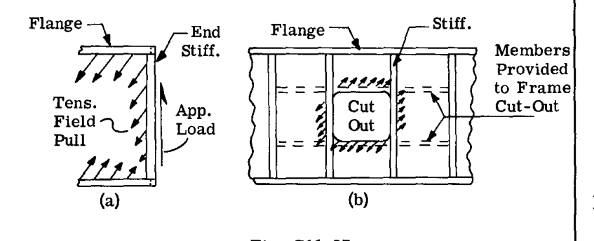

Fig. C11.27

このような端部部材に曲げを発生させる1インチあたりのランニング荷重の成分は、以下の公式によって与えられる：

$$

中立軸に平行な端部部材（ストリンガーなど）の場合、および

$$

中立軸に対して垂直な部材（スチフナまたはフレーム）の場合。端部部材の支持されていない長さが長くなり、 $w$ を受けるようになると、それが負担しなければならない曲げモーメントは大きくなる。

例えば、Art. C11.13における Fig. C11.13 の梁の端部スチフナを考えてみよう。Art. C11.27 のデータを使用すると、

$$

w = k q = .69 (18350 .025) = 388

$$

これは、端部スチフナが他の荷重に加えて曲げを負担するための厳しい荷重状態である。重い部材が必要となる。

曲げを受ける端部部材に対処する一般的な方法は3つあり、その目的は重量を低く抑えることである。

1. 端部部材を単に「強化」してすべての荷重を負担できるようにする（これは支持されていない長さが長い場合には非効率である）。
2. 端部ベイパネルの厚さを増して非座屈にするか、または $k$ を減少させ、それによって端部部材に曲げを発生させるランニング荷重を減少させる（これは通常、大きなパネルに対しては非効率である）。
3. 端部部材を支持するための追加部材（スチフナ）を提供し、それによって $w$ による曲げモーメントを減少させる（これには追加の部品が必要である）。

実際には、これらの方法の組み合わせが最適である場合が多い。

上記の補強方法(3)を検討する。これは、ベイ内の局所的なせん断力を増加させることがあるため、考慮する必要がある。端部スチフナを曲げから支持するために、3つの追加スチフナが（この場合は等間隔で）追加され、Fig. C11.13 の梁について生じる端部ベイの内部荷重を分析し、Art. C11.27（NACA 方法）の分析が使用されたと仮定する。

Fig. C11.28a は、端部ベイとそれに加えられる荷重を示している。

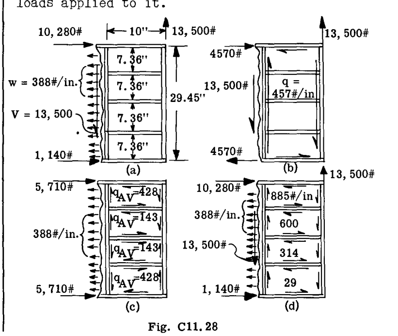

Fig. C11.28

Fig. (a) には2組の適用荷重があることに注意されたい。1つは 13500 lb. の基本的な適用せん断荷重であり、もう1つは、このセクションで先に $388 \text{ lb./in.}$ として計算された張力場荷重の成分 $w$ である。

Fig. (b) は、適用された 13500 lb. 荷重による、すべてのパネルで一定と仮定された端部ベイパネル内のせん断流を示している。せん断流は、端部部材に作用する状態で示されている。

Fig. (c) は、適用された荷重 $w$ によるパネル内のせん断流を示している。平均的なせん断流（各パネルの中央）が示されている。実際には、端部ベイ内のせん断流は、最大 $q = 388 \times \frac{29.45}{2 \times 10} = 571 \text{ lb./in.}$ から、中央での $0 \text{ lb./in.}$ まで変化する。この変化の各ベイの中央における値が、分析目的のために示されている。

Fig. (d) では、最終的な（予備的な）荷重を得るために、(b) と (c) の荷重システムが加算されている。ここでは、端部ベイの上部2つのパネルにおけるせん断流が、他のベイに存在する $q = \frac{13500}{29.45} = 457 \text{ lb./in.}$ の公称値から大幅に増加していることがわかる。これは、この領域における斜め引張効果が（同じウェブ厚さに対して）より大きくなることを意味し、上部フランジ、端部スチフナ、追加されたサポートスチフナ、リベット、ウェブなどをチェックする際に、ここで局所的に考慮されなければならない。

基本的な内部荷重が決定されたら、端部ベイに関与する部材は、Art. C11.14 から C11.26 の方法とデータを使用して強度を確認することができる。上部に追加されたサポートスチフナの場合のように、隣接するベイでせん断流が異なる場合は、スチフナの強度を確認する際に $q$ と $k$ の平均値を使用する必要がある。式(57)は、隣接するベイにおいて等しいせん断力を前提としている。

一般に、構造ネットワークにおいてパネルごとにせん断流が変化する場合に、正確な張力場荷重の変化を計算する単純な分析方法はない。上記のアプローチは、設計目的で使用できる初歩的な「近似」にすぎない。すべてのマージンがゼロに近い場合は、実証用の要素試験が適切である。

[figure not shown]

Fig. C11.16

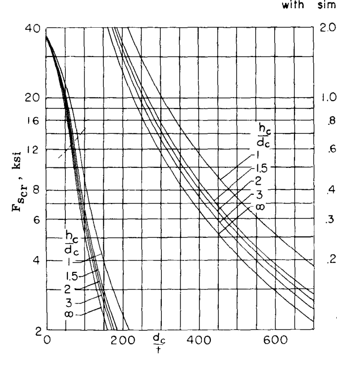

Fig. C11.17

[figure not shown]

Fig. C11.18

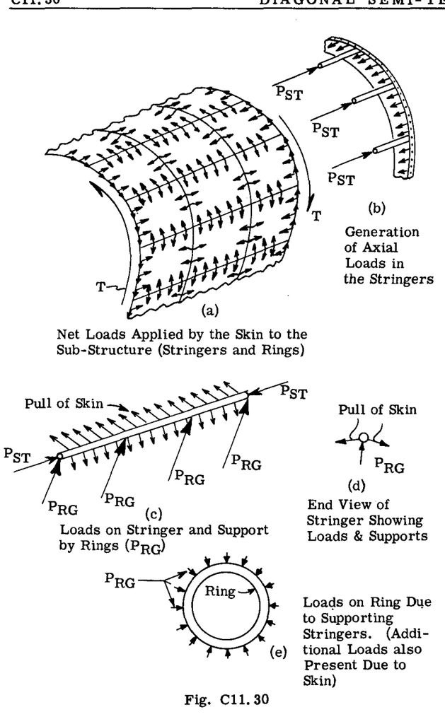

Fig. C11.30

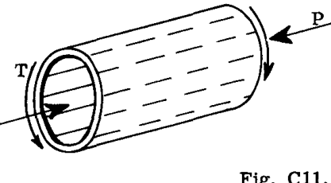

Fig. C11.31

5. スキンを互いにつなぎ合わせる、またはスキンを端部リングに固定するファスナーは、せん断パネルタイプの荷重だけでなく、平面ウェブ梁の場合と同様に、通常の荷重も受ける。また、斜め座屈によるスキンの「ひだ」は、ストリンガーやリングのビードを横切って伸びようとするため、リベットをこじ開けるように作用する。

ここで理解すべき重要なことは、純粋なねじり荷重のみが加えられた場合でも、ストリンガーとリングにかなりの軸方向荷重が発生したということである。そして、ストリンガーや「フローティング」タイプのリングにも、いくらかの曲げモーメントが誘発されている。

ここで、ねじり荷重が加えられているのと同時に、Fig. C11.31 に示すように、増加する圧縮軸荷重 $P$ が同時に加えられていると仮定する。

$P$ の存在により、以下のような現象が発生する。

1. ストリンガーは当然、それらの間で分割される圧縮荷重 $P$ を負担しなければならない。助けとなる「有効」なスキンがいくらか存在する。
2. あまり明らかではないが非常に重要なのは、ねじり $T$ による斜め引張荷重が、軸方向荷重 $P$ の存在によってかなり影響を受けるという事実である。 $T$ に対して $P$ が大きくなるほど、斜め引張効果への影響は大きくなる。これは以下の通りである。
1. スキンパネルは、圧縮方向にも軸方向に歪みを受けるため、より低いねじり荷重で座屈するようになる。実際には、圧縮座屈とせん断座屈からなる「複合」座屈が存在する。これは、後述する相互作用方程式から得ることができる。
2. 限界せん断座屈応力が低くなるため、斜め引張係数 $k$ は大きくなる。
3. $k$ に依存するすべての斜め引張効果が増加する。これらには、ストリンガーに誘発される軸方向荷重、ストリンガーを内側に曲げる通常荷重、リングに誘発される荷重、およびファスナーが受ける荷重が含まれる。
4. 斜め引張の角度はより大きくなり、45度により近くなる。

したがって、圧縮の効果は、斜め引張による荷重を増加させることであることがわかる。

ここで、圧縮される代わりに、軸方向荷重 $P$ が引張であると仮定する。この場合、 $T$ による斜め引張効果は減少する。

1. ストリンガーとスキンは $P$ による引張を受け、これは斜め引張による圧縮に対抗する。

[figure not shown]

Fig. C11.21

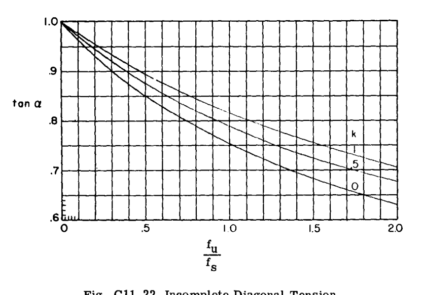

Fig. C11.22

[figure not shown]

Fig. C11.23

[figure not shown]

Fig. C11.24

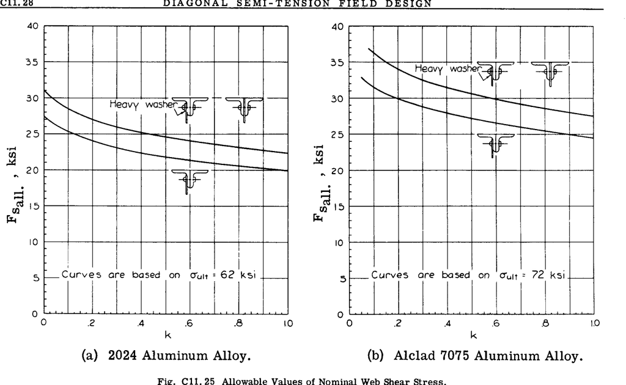

Fig. C11.25

[figure not shown]

Fig. C11.26